# Answering questions with descriptive statistics

Ben Whalley, Paul Sharpe, Sonja Heintz

# Overview

[video not shown]

**Video summary**

- We collect data to *answer questions*
- The first step is to describe and visualise pattens in our data
- Common descriptions include measures of:
  - *central tendency* and *spread* of continuous variables (and of *differences* in these values)
  - the *frequency* of categorical responses
  - the *relationships* between variables (correlation)
- After that, we can quantify our confidence (see next workshop)
- Visualisation is an undervalued method for understanding data

**Full Transcript**

An important task for researchers is to *answer questions using data*. We can often divide this activity into:

1. **Describing patterns in the data**
2. **Quantifying how *sure* we are about those patterns**

This session is all about describing and visualising patterns in the data to answer research questions.

In this session we will cover four techniques psychologists use to answer research questions.

1. summarising numeric variables by *central tendency* and *spread*
2. calculating the *frequency* of categorical responses
3. calculating *differences* between scores or groups
4. describing *relationship* between two variables

In the past psychologists have often neglect the first part (spotting and describing patterns) and jumped straight to the second — for example, they have been very keen to run hypothesis tests and calculate *p* values!

A more contemporary approach places much more emphasis on describing and visualising the data, to understand it, before trying to quantify the evidence it provides and make inferences from it.

We have already seen how to implement some of these techniques in R (e.g. using `summarise()`). However, more important than any specific technique in R is this idea that we *collect data to answer questions* (not just for it’s own sake!).

# Central tendency and spread

[video not shown]

**Video summary**

- the *central tendency* of the data describes the “middle” of a set of values
- the mean and median are the most common measures
- measures of *spread* or distribution of the data show where most of the values fall (i.e. what range of values are most likely)
- common measures are the standard deviation or interquartile range
- we have already seen how to calculate these statistics using `summarise()` and `group_by()`

**Code examples**

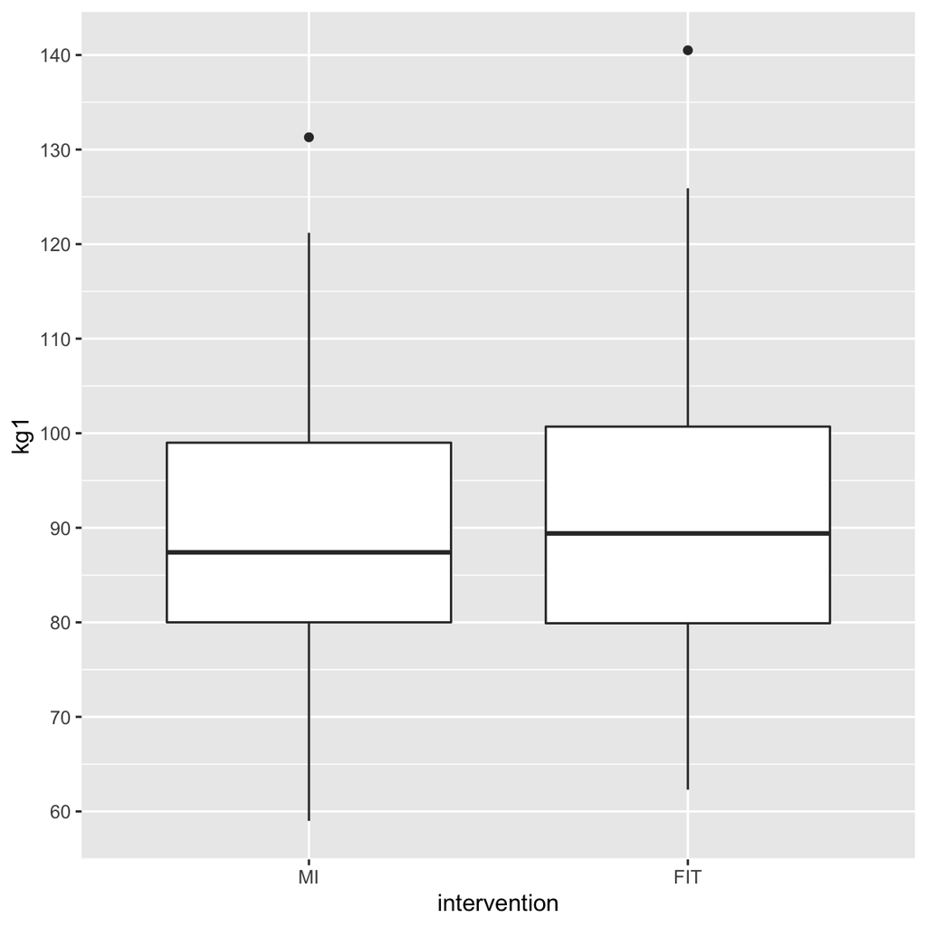

```r
# this is a recap of earlier material

# calculate an average
# typical weight at baseline in the FIT trial
funimagery %>%
  summarise(mean(kg1))
  mean(kg1)
1  90.70536


# a boxplot shows the interquartile range (IQR) as the box.
# The IQR is the range which includes 50% of values
funimagery %>%
  ggplot(aes(intervention, kg1)) +
  geom_boxplot() +
  scale_y_continuous(n.breaks = 10) # this extra line just adds more marks on the y axis
```

**Full Transcript**

If we have a single numeric variable we can describe:

1. the *central tendency* of the data: e.g. mean, median
2. the *spread* or distribution of the data: e.g. the standard deviation or interquartile range

Even simple descriptive statistics like the mean or standard deviation enable us to *answer research questions*. For example, if we consider the `funimagery` data describing the RCT of functional imagery training, we could ask:

- *“what was the typical weight of participants at baseline?”* or
- *“what was the **range** in which most participants’ weight fell?”*

You have already seen how techniques like `group_by()` and `summarise()`, or graphs like boxplots, can help calculate and present these *descriptive statistics*.

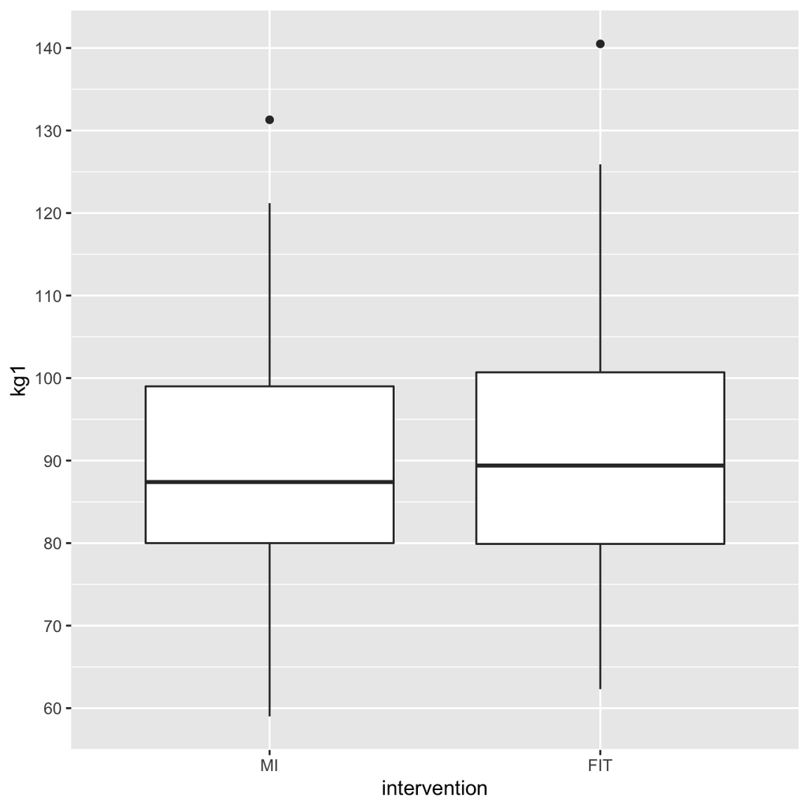

```r
# (this is a recap of earlier material)
# typical weight at baseline
funimagery %>%
  summarise(mean(kg1))
  mean(kg1)
1  90.70536


# a boxplot showing the IQR as the box. The IQR includes 50% of participants
# so, we can see 50% of participants weighed between 80 and 100kg at baseline
funimagery %>%
  ggplot(aes(intervention, kg1)) +
  geom_boxplot() +
  scale_y_continuous(n.breaks = 10) # this extra line just adds more marks on the y axis
```

## Describing *differences*

The previous table and boxplot showed patients’ weights at the start of the study.

There is also a variable in this dataset called `weight_lost_end_trt`, which shows how much weight people lost between starting and completing FIT or MI. In a previous session we made a boxplot like this:

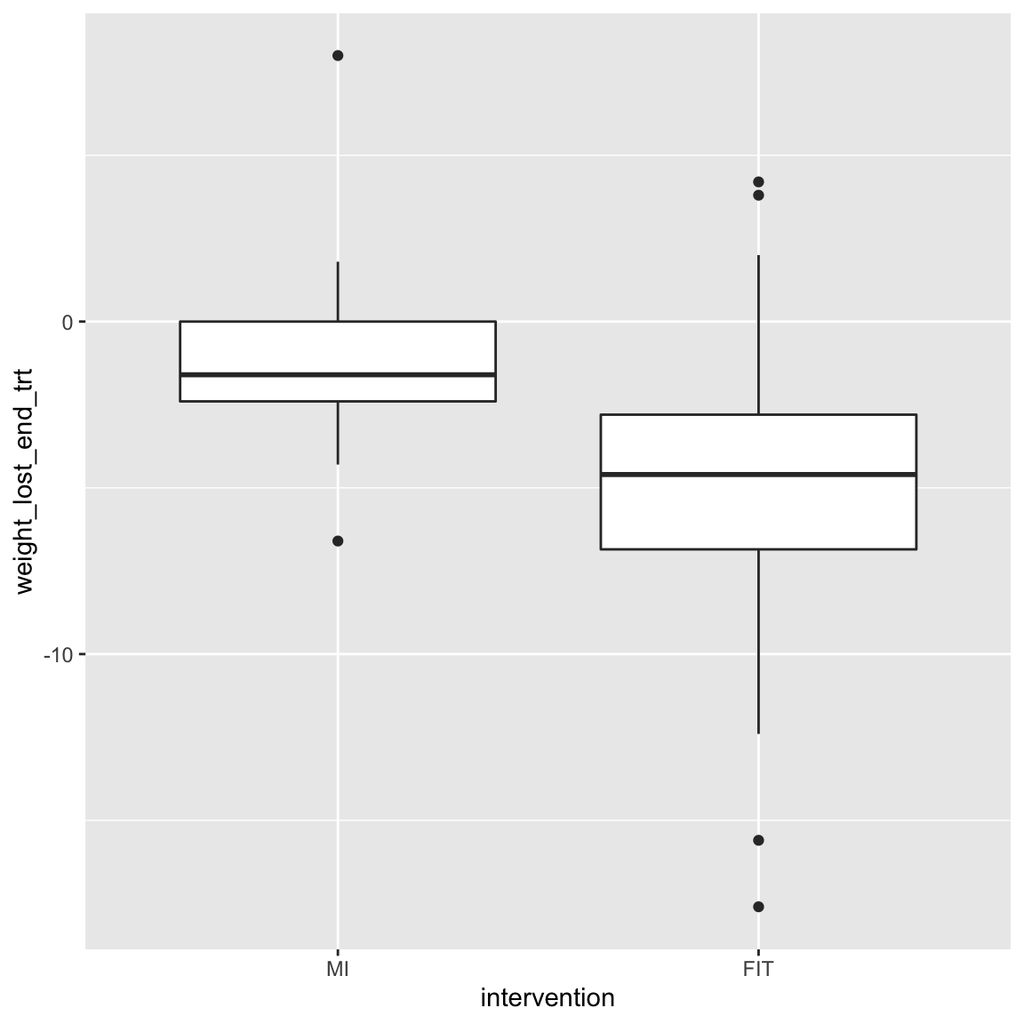

However, in clinical trials, it’s important to measure participants for longer periods to judge whether the effect of a treatment is sustained. Interventions for obesity and overweight can be successful, but patients may later regain weight (Hall & Kahan, 2018). Estimating how long weight loss is sustained is important because it changes the long term prognosis of patients, and how cost-effective an intervention is.

The `funimagery` data come from a study which followed people for 6 months after completing treatment (12 months after joining the study). The `kg1` column records weights at baseline, and the`kg3` columns records observations made at the end of follow-up

This means we can calculate weight loss from baseline to follow-up (not just the end of treatment, which has already been done for us).

We need to create a *new column* in our dataset. Let’s call this `weight_lost_end_followup`.

To calculate this new column we need to subtract weight at baseline (`kg1`) from weight at the end of follow-up (`kg3`).

In R, we can do this with the `mutate` function:

```r
# use `mutate` to create a NEW COLUMN of data
# this code shows the result just below the code chunk
funimagery %>%
  mutate(weight_lost_end_followup = kg3 - kg1)
    gender age   kg1   kg2   kg3 person intervention weight_lost_end_trt weight_lost_end_followup
1        f  44 107.8 106.7 106.0      4           MI                -1.1                     -1.8
2        f  32 107.0 105.4 105.9      5           MI                -1.6                     -1.1
3        f  33  99.5 101.0  98.8      6           MI                 1.5                     -0.7
4        f  21  80.0  79.0  78.0      7           MI                -1.0                     -2.0
5        f  27  81.0  80.0  80.0      8           MI                -1.0                     -1.0
6        f  56  59.0  57.0  60.0      9           MI                -2.0                      1.0
7        f  50  95.0  92.0  92.0     10           MI                -3.0                     -3.0
8        m  57  90.0  87.0  87.0     11           MI                -3.0                     -3.0
9        f  34  87.0  87.0  86.4     12           MI                 0.0                     -0.6
10       f  25 121.2 123.0 119.7     13           MI                 1.8                     -1.5
11       m  70  84.0  81.9  84.0     14           MI                -2.1                      0.0
12       f  56 100.0  97.2  98.0     15           MI                -2.8                     -2.0
13       f  55  87.4  85.0  84.9     16           MI                -2.4                     -2.5
14       f  43 100.4  99.1 100.0     17           MI                -1.3                     -0.4
15       m  37  89.5  91.0  91.5     18           MI                 1.5                      2.0
16       m  45  84.2  85.6  86.2     19           MI                 1.4                      2.0
17       f  60  92.3  88.0  88.0     20           MI                -4.3                     -4.3
18       f  51 112.0 109.0 109.0     21           MI                -3.0                     -3.0
19       f  21  76.0  75.0  76.2     22           MI                -1.0                      0.2
20       m  43  89.5  87.2  88.0     23           MI                -2.3                     -1.5
21       f  21 118.0 116.7 115.0     24           MI                -1.3                     -3.0
22       m  19 102.4  99.4 100.0     25           MI                -3.0                     -2.4
23       m  65  79.4  80.2  79.5     26           MI                 0.8                      0.1
24       m  40  88.0  85.9  87.8     27           MI                -2.1                     -0.2
25       f  45  85.0  83.0  80.0     28           MI                -2.0                     -5.0
26       f  66  67.5  65.4  65.6     29           MI                -2.1                     -1.9
27       f  38  91.3  91.5  89.0     30           MI                 0.2                     -2.3
28       f  55  88.3  85.0  87.1     31           MI                -3.3                     -1.2
29       f  52  86.2  85.0  85.0     32           MI                -1.2                     -1.2
30       f  41  77.4  76.7  80.1     33           MI                -0.7                      2.7
31       m  40  79.0  76.5  80.0     34           MI                -2.5                      1.0
32       m  44  99.0  98.2  95.0     35           MI                -0.8                     -4.0
33       f  51  87.0  87.0  85.0     36           MI                 0.0                     -2.0
34       f  56  85.0  82.3  85.2     37           MI                -2.7                      0.2
35       m  40  69.0  66.1  67.0     38           MI                -2.9                     -2.0
36       f  30 119.0 127.0 123.0     39           MI                 8.0                      4.0
37       m  51 103.5 104.7 103.0     40           MI                 1.2                     -0.5
38       m  35  73.7  71.6  71.2     41           MI                -2.1                     -2.5
39       f  24  87.0  84.7  86.0     42           MI                -2.3                     -1.0
40       f  36 131.3 132.0 132.0     43           MI                 0.7                      0.7
41       f  47 120.0 120.0 122.0     44           MI                 0.0                      2.0
42       f  41  87.5  86.2  85.0     45           MI                -1.3                     -2.5
43       f  54  90.0  87.7  86.0     46           MI                -2.3                     -4.0
44       f  20  90.0  88.0  88.0     47           MI                -2.0                     -2.0
45       f  60  87.0  85.2  84.0     48           MI                -1.8                     -3.0
46       f  33  83.0  81.0  80.0     49           MI                -2.0                     -3.0
47       f  23  72.0  71.2  71.0     50           MI                -0.8                     -1.0
48       f  50  75.0  72.0  70.0     51           MI                -3.0                     -5.0
49       f  45  69.0  69.0  68.0     52           MI                 0.0                     -1.0
50       f  34  85.4  78.8  74.7     53           MI                -6.6                    -10.7
51       f  35  76.5  76.3  78.0     54           MI                -0.2                      1.5
52       m  56  74.1  70.8  72.0     55           MI                -3.3                     -2.1
53       f  33  93.4  94.5  93.5     58           MI                 1.1                      0.1
54       f  56  82.1  76.0  74.0     59          FIT                -6.1                     -8.1
55       f  20  90.5  88.0  84.5     60          FIT                -2.5                     -6.0
56       f  60 120.4 109.2  98.0     61          FIT               -11.2                    -22.4
57       f  59  97.2  94.6  90.0     62          FIT                -2.6                     -7.2
58       f  45  78.0  74.8  68.0     63          FIT                -3.2                    -10.0
59       f  39  79.9  75.8  68.5     64          FIT                -4.1                    -11.4
60       m  40 101.2  98.7  95.3     65          FIT                -2.5                     -5.9
61       f  25 111.0 100.0  90.0     66          FIT               -11.0                    -21.0
62       m  28  79.6  83.8  86.4     67          FIT                 4.2                      6.8
63       m  22  62.3  63.4  60.0     68          FIT                 1.1                     -2.3
64       f  26  76.8  70.0  65.0     69          FIT                -6.8                    -11.8
65       m  42  95.9  97.9  85.0     70          FIT                 2.0                    -10.9
66       f  35  84.7  82.0  80.0     71          FIT                -2.7                     -4.7
67       m  70 116.4 111.8 113.5     72          FIT                -4.6                     -2.9
68       f  46 100.2  94.0  90.0     73          FIT                -6.2                    -10.2
69       m  22 140.5 138.7 146.8     74          FIT                -1.8                      6.3
70       f  46  91.7  79.3  75.2     75          FIT               -12.4                    -16.5
71       f  60  85.4  80.2  70.0     76          FIT                -5.2                    -15.4
72       f  43  86.7  85.7  80.0     77          FIT                -1.0                     -6.7
73       f  58 112.6  95.0  98.5     78          FIT               -17.6                    -14.1
74       m  40 113.9 104.0  95.0     79          FIT                -9.9                    -18.9
75       f  60  75.5  70.0  70.0     80          FIT                -5.5                     -5.5
76       f  23  99.5  96.5  90.0     81          FIT                -3.0                     -9.5
77       f  55 101.5  96.1  97.0     82          FIT                -5.4                     -4.5
78       m  27  95.9  87.2  84.1     83          FIT                -8.7                    -11.8
79       f  33  94.9  90.9  92.0     84          FIT                -4.0                     -2.9
80       f  40  83.5  74.0  73.9     85          FIT                -9.5                     -9.6
81       f  50 107.0 104.4  95.0     86          FIT                -2.6                    -12.0
82       f  53  77.8  73.2  78.1     87          FIT                -4.6                      0.3
83       f  69  89.8  86.9  80.0     88          FIT                -2.9                     -9.8
84       m  48  88.9  85.2  85.0     89          FIT                -3.7                     -3.9
85       f  58 103.9  98.7  97.0     90          FIT                -5.2                     -6.9
86       m  35  64.0  59.0  58.0     91          FIT                -5.0                     -6.0
87       f  53  74.0  70.0  65.0     92          FIT                -4.0                     -9.0
88       m  36  98.3  89.0  94.0     93          FIT                -9.3                     -4.3
89       f  24  88.4  82.0  75.0     94          FIT                -6.4                    -13.4
90       f  46  88.6  84.6  85.0     95          FIT                -4.0                     -3.6
91       f  20  94.9  90.1  90.0     96          FIT                -4.8                     -4.9
92       f  62  76.3  72.1  72.0     97          FIT                -4.2                     -4.3
93       f  51 110.0 100.5  99.0     98          FIT                -9.5                    -11.0
94       f  42  82.0  78.2  70.0     99          FIT                -3.8                    -12.0
95       f  44 103.0  87.4  79.0    100          FIT               -15.6                    -24.0
96       f  23  95.9  93.6  93.2    101          FIT                -2.3                     -2.7
97       f  20  95.9  87.2  94.2    102          FIT                -8.7                     -1.7
98       f  56  90.4  79.0  85.0    103          FIT               -11.4                     -5.4
99       f  42  68.0  68.0  73.8    104          FIT                 0.0                      5.8
100      f  35 125.9 122.3 124.5    105          FIT                -3.6                     -1.4
101      f  64  82.4  77.8  81.8    106          FIT                -4.6                     -0.6
102      f  29  70.8  63.9  60.0    107          FIT                -6.9                    -10.8
103      f  72  73.3  73.5  73.4    108          FIT                 0.2                      0.1
104      m  48  78.7  79.5  70.0    109          FIT                 0.8                     -8.7
105      m  46  84.0  80.0  75.3    110          FIT                -4.0                     -8.7
106      f  66  72.6  68.0  64.0    111          FIT                -4.6                     -8.6
107      f  69  89.4  83.6  86.0    112          FIT                -5.8                     -3.4
108      f  64 121.4 114.0 114.0    113          FIT                -7.4                     -7.4
109      m  39 101.8  97.1  94.0    114          FIT                -4.7                     -7.8
110      m  50  80.7  75.2  74.1    115          FIT                -5.5                     -6.6
111      f  54  80.5  84.3  82.0    116          FIT                 3.8                      1.5
 [ reached 'max' / getOption("max.print") -- omitted 1 rows ]
```

[RUN THE CODE ABOVE AND SHOW STUDENTS THE RESULT. POINT OUT THAT THIS HAS NOT BEEN STORED ANYWHERE — JUST DISPLAYED IN THE RSTUDIO GUI BELOW THE CODE CHUNK]

We almost certainly want to STORE this extra column so we can use it again. To do this we create a *copy* of the whole `funimagery` dataset by *assigning* the result of `mutate())`

The assignment operator is the left hand arrow, `<-`:

```r
funimagery.edited <- funimagery %>%
  mutate(weight_lost_end_followup = kg3 - kg1)
```

[SHOW STUDENTS NEW VARIABLE HAS BEEN CREATED IN THE ENVIRONMENT WINDOW]

So the code above:

- takes the `funimagery` data and pipes it to the `mutate()` function, which
- adds a new column, called `weight_lost_end_followup`
- this new column is made by subtracting `kg1` (baseline) from `kg3` (end of followup)
- stores the new dataset (with the extra column) in a new *variable* called `funimagery.edited`:

We can then use this new variable to do more work, like making a new boxplot:

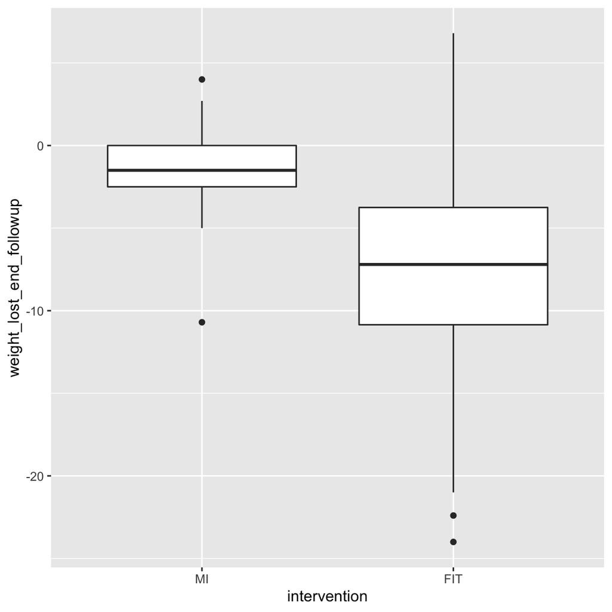

```r
# boxploot of weight lost at end of follow-up using new column
funimagery.edited %>%
  ggplot(aes(intervention, weight_lost_end_followup)) +
  geom_boxplot()
```

If anything, it looks like the difference between groups is even BIGGER after follow-up than it was at the end of treatment, which is very promising.

# The *frequency* of responses

[video not shown]

**Video summary**

- We can’t calculate a mean or SD for Categorical variables
- We still want to describe the pattern of responses
- We can use `count()` and `group_by()` to make a *frequency table*
- This is common in journal results sections (e.g. to describe characteristics of the sample like gender or education)

**Code examples**

**Full Transcript**

With categorical data it’s not possible to calculate averages, but it is still useful to be able to describe the data. For example, if we were thinking about the `earnings` dataset we might ask:

- *“How many men and women were recruited?”*
- *“What proportion of participants worked in the public sector?”*
- *"Was this proportion similar for men and women?*"

The earnings data contained variables called `gender` and `job` which can answer these questions:

```r
earnings %>% glimpse
Rows: 4,483
Columns: 8
$ id        <dbl> 1, 5, 6, 7, 10, 12, 13, 17, 18, 19, 20, 21, 22, 24, 27, 28, 33, 35, 36, 37, 38, 42, 44, 45, 48, 50, …
$ gender    <chr> "female", "male", "male", "female", "female", "female", "male", "female", "female", "male", "male", …
$ native    <chr> "native", "native", "native", "native", "native", "native", "native", "native", "native", "native", …
$ blind     <chr> "no", "no", "no", "no", "no", "no", "no", "no", "no", "no", "no", "no", "no", "no", "no", "no", "no"…
$ hours     <dbl> 50, 50, 60, 20, 36, 60, 20, 32, 50, 50, 40, 40, 40, 40, 40, 20, 42, 50, 40, 40, 40, 40, 40, 40, 40, …
$ job       <chr> "private", "private", "private", "private", "private", "private", "private", "private", "private", "…
$ income    <dbl> 77194, 712505, 588751, 27535, 8154, 447768, 120091, 348543, 41493, 63909, 109104, 67422, 125548, 798…
$ education <chr> "high-school", "bachelor", "high-school", "bachelor", "high-school", "master", "bachelor", "bachelor…
```

To count the frequency of different responses we can use the `count` function.

```r
# this gives us the total number of rows
earnings %>% count()
     n
1 4483

# numbers of men an women
earnings %>%
  group_by(gender) %>%
  count()
# A tibble: 2 x 2
# Groups:   gender [2]
  gender     n
  <chr>  <int>
1 female  2130
2 male    2353

# later we'll show ways of doing arithmetic on the results, but for now
# if we simply divide men/total we get the proportion/percentage of men
2353 / 4483 * 100
[1] 52.48717



# we can do the same for job:
earnings %>%
  group_by(job) %>%
  count()
# A tibble: 4 x 2
# Groups:   job [4]
  job         n
  <chr>   <int>
1 charity   326
2 nopay       3
3 private  3447
4 public    707

# proportion in the private sector
3447 / 4483 * 100
[1] 76.89048


# we can use group_by again to get the split for men and women:
earnings %>%
  group_by(job, gender) %>%
  count()
# A tibble: 8 x 3
# Groups:   job, gender [8]
  job     gender     n
  <chr>   <chr>  <int>
1 charity female   210
2 charity male     116
3 nopay   female     2
4 nopay   male       1
5 private female  1507
6 private male    1940
7 public  female   411
8 public  male     296

1940
[1] 1940
```

- Exercise where they have to do this

```r
earnings %>% group_by(education) %>% count()
# A tibble: 5 x 2
# Groups:   education [5]
  education        n
  <chr>        <int>
1 bachelor      1057
2 doctor          86
3 grade-school   365
4 high-school   2445
5 master         530
```

```r
earnings %>%
  group_by(gender, education) %>%
  count() %>%
  pivot_wider(names_from = "gender", values_from="n")
# A tibble: 5 x 3
# Groups:   education [5]
  education    female  male
  <chr>         <int> <int>
1 bachelor        530   527
2 doctor           33    53
3 grade-school    126   239
4 high-school    1157  1288
5 master          284   246
```

# Relationships

[video not shown]

**Video summary**

**Code examples**

**Full Transcript**

When we have 2 or more continuous variables, we can also describe the *relationships* between them.

We have already seen how to use scatterplots to show the relationship between variables. For example, using the trial data again, we can show the relationship between weight at baseline and end of treatment:

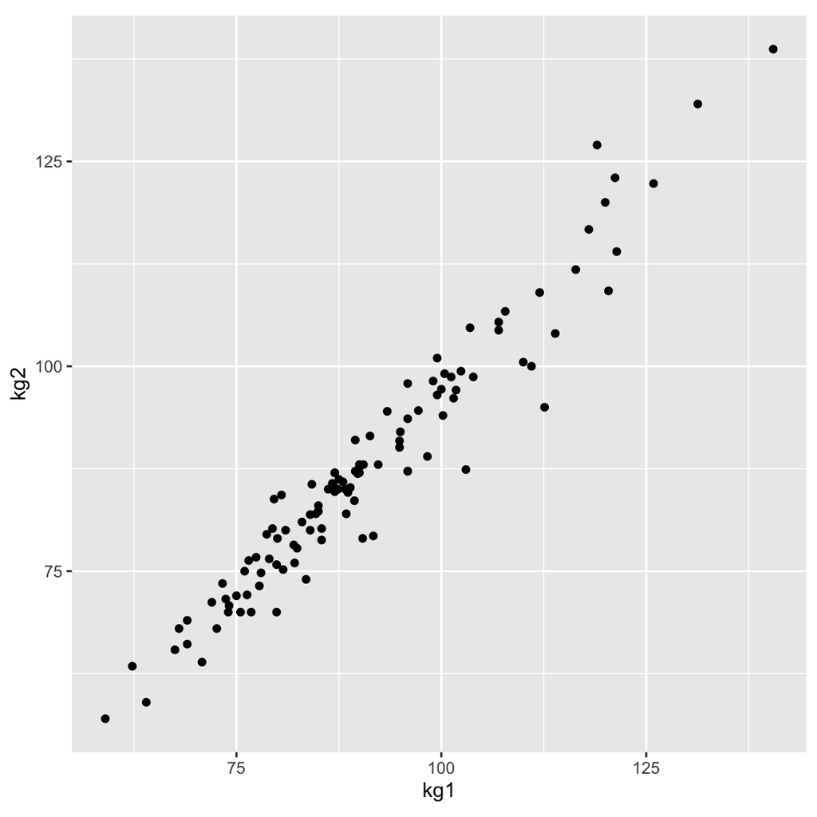

The scatterplot shows there is a *strong, postive relationship* between participants’ weights at baseline and after treatment.

Even though participants’ weight does change in the trial, it is not by much. We can see this by the way the points for each participant line up close to the diagonal: if their weight stayed exactly the same we would see all the points in a line at 45 degrees from the graph origin.

*The scatterplot is a powerful description of the data in its own right*. Psychologists have tended to undervalue data visualisation, so it’s important to make plots like this with your own data.

However, we do sometimes want to summarise the relationship further and describe the strength of the relationship in a single number. For this we use correlation.

## Correlation

A *correlation* is a single number which describes *how related* two continuous variables are.

For a correlation to work the relationship between the variables must be *linear*. That is, the line on the graph has to be (fairly) straight (as it is in the example above).

To calculate a correlation we use the `correlate()` function in the `corrr` library.

First we load the library:

```r
library(corrr)
```

Next we need to select the columns we want to correlate. In this case we want to use `kg1`, `kg2`, and `kg3` in the `funimagery` dataset.

We can use `select()` to choose only these columns, and then use another pipe to send just those columns to `correlate()`:

```r
# select weight at baseline and follow-up an correlate them
funimagery %>%
  select(kg1, kg2, kg3) %>%
  correlate()
# A tibble: 3 x 4
  term     kg1    kg2    kg3
  <chr>  <dbl>  <dbl>  <dbl>
1 kg1   NA      0.969  0.934
2 kg2    0.969 NA      0.969
3 kg3    0.934  0.969 NA
```

The result of `correlate()` is a new dataset.

It has one column for each of the variables we selected, plus an extra column called `term` for the variable being correlated.

The numbers represent the **correlation coefficient** for each pair of variables. The correlation between a variable and itself is always perfect, so the numbers on the diagonal of the table are not shown (they are `NA`).

[SHOW AND TALK THROUGH SOME OF THE VALUES IN THE TABLE AT THIS POINT]

We can see here that the correlations are all above 0.9, which is very high.

This isn’t surprising though. Even when trying to lose weight if we measure the same person twice these observations are likely to be quite closely related.

### Interpreting correlation coefficients

A *correlation coefficient* (the number) can be between -1 and 1. It is never outside this range.

The plot below shows examples o positive an negative correlations:

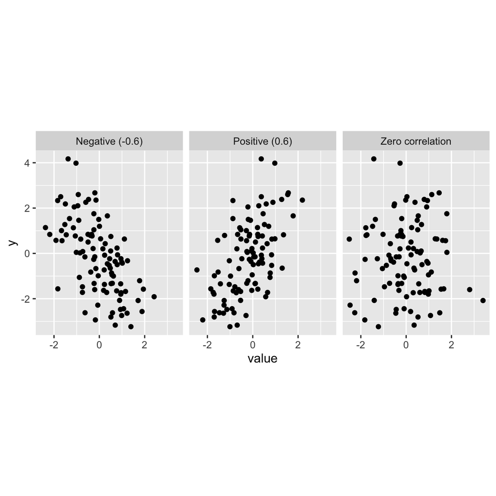

However to get a real feel for what correlations of different values look like, you can play this game:

[DEMO http://guessthecorrelation.com]

[figure not shown]

# Summary

*Both plots and descriptive statistics are valuable ways of answering questions from the data.* Psychologists sometimes neglect them (especially plots) but they are important steps in developing understanding.

- Boxplots are useful for describing the differences between groups
- Scatterplots and smoothed-line plots help describe relationships

- What is the correlation between `power` and `engine_size` in the `fuel` dataset?

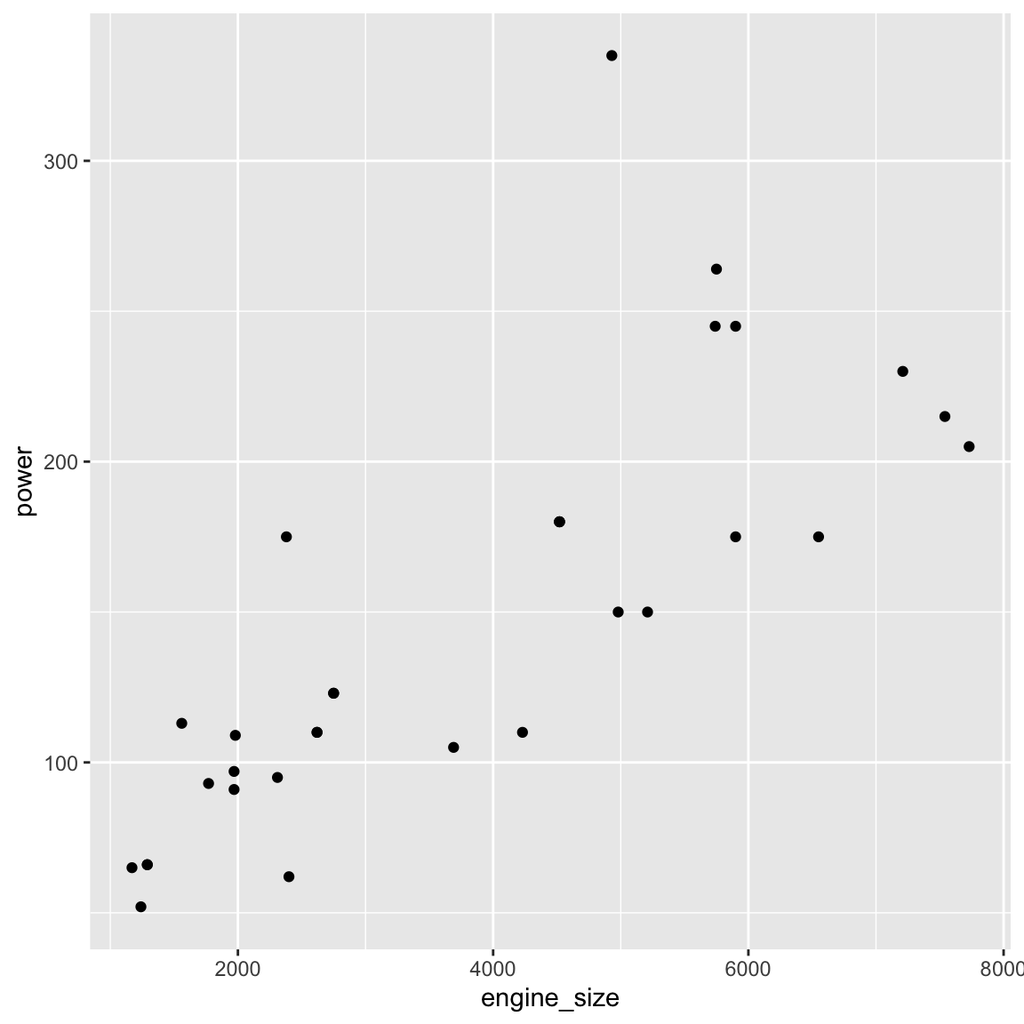

```r
library(corrr)
fuel %>% ggplot(aes(engine_size, power)) + geom_point()
```

```r
fuel %>% select(power, engine_size) %>% correlate()
# A tibble: 2 x 3
  term         power engine_size
  <chr>        <dbl>       <dbl>
1 power       NA           0.791
2 engine_size  0.791      NA
```

# Extension exercises

Please remember that these extension exercises are *not* required to pass the course. We include them because find that some students work through these materials much more quickly than others — perhaps because they have more previous experience with programming — and we aim to give all students the opportunity to stretch their skills.

If you do find you have extra time, however, these exercises are intended to provide additional practice in the technqiues taught here, and to be useful preparation for using R independently in a stage 4 or MSc research project.

- Correlations require that there is a *linear relationship* between the two variables
- Which pairs of numeric column in the `fuel` dataset would be suitable for correlation?

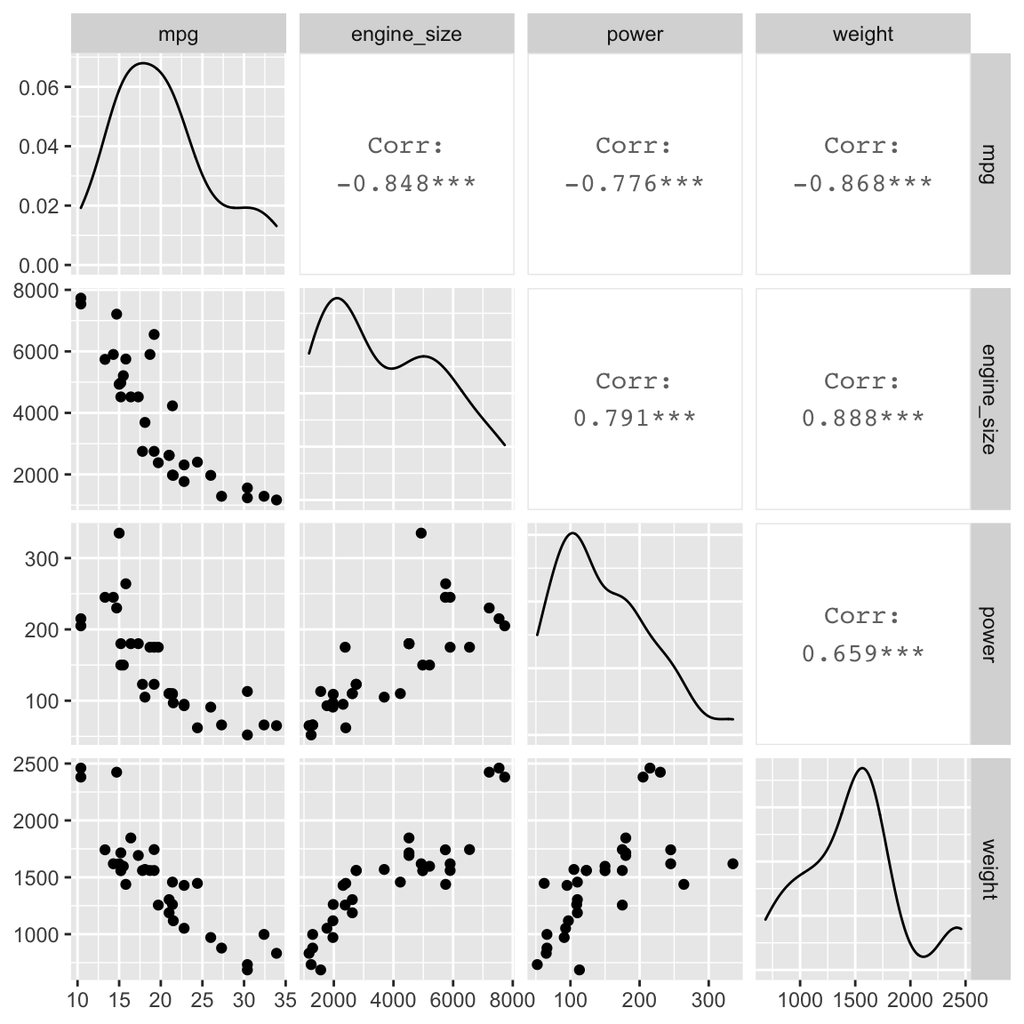

```r
# perhaps not mpg and engine_size or power, or engine_size+weight
fuel %>% select(mpg, engine_size, power, weight) %>%
  GGally::ggpairs()
```

# Check your knowledge

# References

Hall, K. D., & Kahan, S. (2018). Maintenance of lost weight and long-term management of obesity. *Medical Clinics*, *102*(1), 183–197.